# Characterizing Automobiles

Author

Jeffrey Smith

Published

March 17, 2025

# Setup

- Setup

```r
sh <- suppressPackageStartupMessages
sh(library(tidyverse))
sh(library(caret))
sh(library(fastDummies))
sh(library(class))
sh(library(ISLR)) # for the "Auto" dataframe
sh(library(tidytext))
sh(library(moderndive))
sh(library(thematic))
sh(library(pROC))
sh(library(scales))
thematic_rmd(bg = "#111", fg = "#eee", accent = "#eee")
```

# Dataframe

- We use the `Auto` dataframe.

```r
head(Auto)
```

```
  mpg cylinders displacement horsepower weight acceleration year origin
1  18         8          307        130   3504         12.0   70      1
2  15         8          350        165   3693         11.5   70      1
3  18         8          318        150   3436         11.0   70      1
4  16         8          304        150   3433         12.0   70      1
5  17         8          302        140   3449         10.5   70      1
6  15         8          429        198   4341         10.0   70      1
                       name
1 chevrolet chevelle malibu
2         buick skylark 320
3        plymouth satellite
4             amc rebel sst
5               ford torino
6          ford galaxie 500
```

- It has the following variable names, which describe various attributes of automobiles.

```r
names(Auto)
```

```
[1] "mpg"          "cylinders"    "displacement" "horsepower"   "weight"
[6] "acceleration" "year"         "origin"       "name"
```

# Multiple Regression

- Run a linear regression model with `mpg` as the dependent variable and `horsepower` and `year` as features (variables).
- Compute and comment on the RMSE.

```r
m1 = lm(mpg ~ horsepower + year, data = Auto)

get_regression_points(m1) %>%
  drop_na(residual) %>%
  mutate(sq_residuals = residual^2) %>%
  summarise(rmse = sqrt(mean(sq_residuals))) %>%
  pluck("rmse")
```

```
[1] 4.371492
```

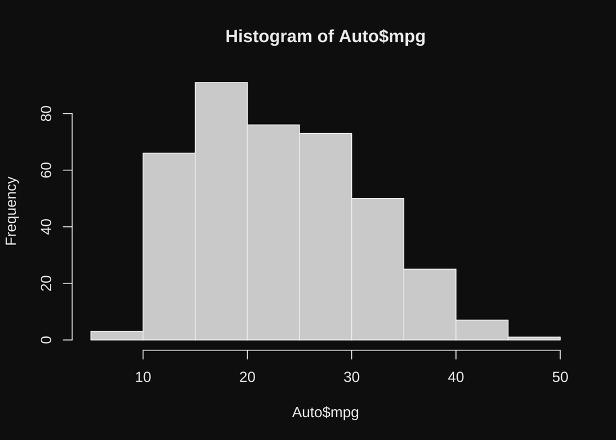

```r
hist(Auto$mpg)
```

```r
var(Auto$mpg)
```

```
[1] 60.91814
```

> The RMSE here was calculated to be 4.3715. Since the RMSE is in the same units as the response variable, and can simply be interpreted as the average absolute error, this RMSE is not that bad. Considering the fact that the range of the response `mpg` variable is 37.6 and that the spread of the data is decent with a sample variance of 60.9181, having an RMSE of 4.3715 is not bad.

# Feature Engineering

- Create 10 features based on the `name` column.
- Remove all rows with a missing value.
- Ensure only `mpg` and the engineered features remain.
- Compute and comment on the RMSE.

```r
wordshehe = Auto %>%
  mutate(name = as.character(name)) %>%
  unnest_tokens(word, name) %>%
  anti_join(stop_words) %>%
  filter(str_detect(string = word, pattern = "[a-z+]")) %>%  # get rid weird non alphas
  filter(str_length(word)>3) %>%  # get rid of strings shorter than 3 characters
  group_by(word) %>%
  summarise(total=n()) %>%
  arrange(desc(total))
mycar = Auto %>%
  mutate(name = tolower(name)) %>%
  mutate(vw = str_detect(name, c("vw|volkswagen")),
         plymouth = str_detect(name, "plymouth"),
         chevrolet = str_detect(name, c("chevy|chevrolet")),
         ford = str_detect(name, "ford"),
         honda = str_detect(name, "honda"),
         buick = str_detect(name, "buick"),
         pontiac = str_detect(name, "pontiac"),
         dodge = str_detect(name, "dodge"),
         toyota = str_detect(name, "toyota"),
         datsun = str_detect(name, "datsun")) %>%
  drop_na() %>%
  select(mpg, vw, plymouth, chevrolet, ford, honda, buick, pontiac, dodge, toyota, datsun)

m2 = lm(mpg ~., data = mycar)

get_regression_points(m2) %>%
  drop_na(residual) %>%
  mutate(sq_residuals = residual^2) %>%
  summarise(rmse = sqrt(mean(sq_residuals))) %>%
  pluck("rmse")
```

```
[1] 6.601227
```

> The RMSE for this second model is 6.6012, which is higher than the RMSE for the first model, indicating this model built purely off of engineered features from the `names` column is worse at predicting `mpg`.

# Classification

- Use either of $K$-NN or Naive Bayes to predict whether an automobile is a `chevrolet` or a `honda`.
- Explain your choice of technique.
- Report on your Kappa value.

```r
auto2 = Auto %>%
  mutate(name = tolower(name)) %>%
  mutate(chevda = str_detect(name, c("chevy|chevrolet|honda")),
         chevda = ifelse(chevda == TRUE, "is", "not"),
         name = as.character(name))

morewords = auto2 %>%
  unnest_tokens(word, name) %>%
  filter(str_detect(string = word, pattern = "[a-z+]")) %>%  # get rid weird non alphas
  filter(str_length(word)>3) %>%  # get rid of strings shorter than 3 characters
  group_by(word) %>%
  mutate(total=n()) %>%
  ungroup()

wordsplot = morewords %>%
    filter(chevda=="is" | chevda=="not") %>%
    group_by(chevda, word) %>%
    count() %>%
    group_by(chevda) %>%
    mutate(proportion = n / sum(n)) %>%
    pivot_wider(id_cols = word, names_from = chevda, values_from = proportion) %>%
    ggplot(aes(x = is, y = not, color = abs(is - not))) +
    geom_abline(color = "gray40", lty = 2) +
    geom_jitter(alpha = 0.1, size = 2.5, width = 0.3, height = 0.3) +
    geom_text(aes(label = word), check_overlap = TRUE, vjust = 1.5) +
    scale_x_log10(labels = percent_format()) +
    scale_y_log10(labels = percent_format()) +
    scale_color_gradient(limits = c(0, 0.001), low = "darkslategray4", high = "gray75") +
    theme(legend.position="none") +
    labs(x = "chevda", y = "Not chevda", title = "Words")

chevda = Auto %>%
  mutate(chevda = str_detect(name, c("chevy|chevrolet|honda"))) %>%
  mutate(fct_year = factor(year),
         fct_cylinders = factor(cylinders),
         chevda = factor(chevda),
         origin = factor(origin)) %>%
  mutate(chevelle = str_detect(name, "chevelle"),
         landau = str_detect(name, "landau"),
         auto = str_detect(name, "auto"),
         wagon = str_detect(name, "wagon")) %>%
  drop_na() %>%
  select(-name, -year, -cylinders, -acceleration, -displacement)



set.seed(5)
thing = createDataPartition(chevda$chevda, p = 0.8, list = FALSE)
train = chevda[thing, ]
test = chevda[-thing, ]

fit = train(chevda ~ .,
             data = train,
             method = "knn",
             tuneLength = 15,
             metric = "Kappa",
             trControl = trainControl(method = "cv", number = 10))
print(confusionMatrix(predict(fit, test),factor(test$chevda)))
```

```
Confusion Matrix and Statistics

          Reference
Prediction FALSE TRUE
     FALSE    65   11
     TRUE      1    0

               Accuracy : 0.8442
                 95% CI : (0.7436, 0.9168)
    No Information Rate : 0.8571
    P-Value [Acc > NIR] : 0.697680

                  Kappa : -0.0244

 Mcnemar's Test P-Value : 0.009375

            Sensitivity : 0.9848
            Specificity : 0.0000
         Pos Pred Value : 0.8553
         Neg Pred Value : 0.0000
             Prevalence : 0.8571
         Detection Rate : 0.8442
   Detection Prevalence : 0.9870
      Balanced Accuracy : 0.4924

       'Positive' Class : FALSE
```

> Here, I chose to use $K$-NN since I cannot assume variables such as cylinders and horsepower are independent, which is a necessary assumption for the use of Naive Bayes. The Kappa value found here was -0.0244, which indicates that this model is worse than random guessing and should be deleted from the system.

# Binary Classification

- Predict whether a car is a `honda`.
- Use model weights.
- Display and comment on an ROC curve.

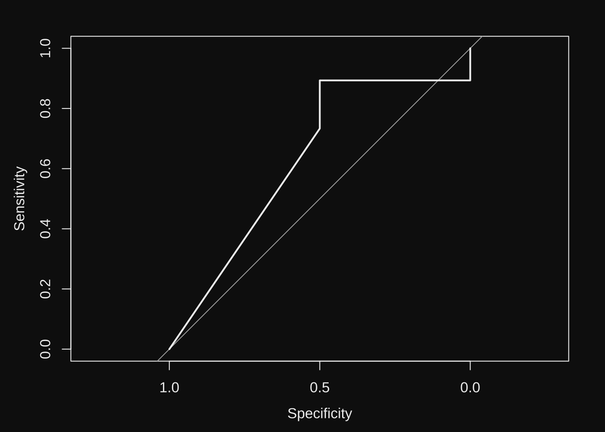

```r
honda = Auto %>%
  mutate(name = as.character(tolower(name))) %>%
  mutate(honda = str_detect(name, "honda")) %>%
  mutate(honda = ifelse(honda == TRUE, "honda", "not")) %>%
  mutate(fct_year = factor(year),
         fct_cylinders = factor(cylinders),
         honda = factor(honda),
         origin = factor(origin)) %>%
  drop_na() %>%
  select(-name, -cylinders, -year)

set.seed(5)
newthing = createDataPartition(honda$honda, p = 0.8, list = FALSE)
train = honda[newthing, ]
test = honda[-newthing, ]


weight_train = train %>%
  mutate(weights=if_else(honda=="honda",30,1))


fit <- train(honda ~ .,
             data = train,
             trControl = trainControl(method = "cv", number = 10),
             method = "glm",
             family = "binomial",
             weights = weight_train$weights)
prob <- predict(fit, newdata = test, type = "prob")[,2]
myRoc <- roc(test$honda, prob)
plot(myRoc)
```

```r
auc(myRoc)
```

```
Area under the curve: 0.63
```

> The ROC curve measures sensitivity, which is the true positive rate, vs the specificity, which is the true negative rate. We can find the area underneath the curve to measure the performance of our model in this regard, with an AUC (area under the curve) value of 1 being a perfect model and an AUC value of 0.5 being one no better than random guessing. For the model made above, the AUC value for the ROC curve was 0.63, which indicates a model that is not that much better than random guessing.

# Ethics

- Based on your analysis, comment on the [Clean Air Act of 1970 and Amendments of 1977](https://www.epa.gov/clean-air-act-overview/evolution-clean-air-act)
- Discuss the civic responsibilities of data scientists for:
  - Big Data and Human-Centered Computing
  - Democratic Institutions
  - Climate Change
- Provide at least one statistical measure for each, such as a RMSE, Kappa value, or ROC curve.

#### Big Data and Human-Centered Computing

```r
m3 = lm(mpg ~ year, data = Auto)
summary(m3)
```

```
Call:
lm(formula = mpg ~ year, data = Auto)

Residuals:
     Min       1Q   Median       3Q      Max
-12.0212  -5.4411  -0.4412   4.9739  18.2088

Coefficients:
             Estimate Std. Error t value Pr(>|t|)
(Intercept) -70.01167    6.64516  -10.54   <2e-16 ***
year          1.23004    0.08736   14.08   <2e-16 ***
---
Signif. codes:  0 '***' 0.001 '**' 0.01 '*' 0.05 '.' 0.1 ' ' 1

Residual standard error: 6.363 on 390 degrees of freedom
Multiple R-squared:  0.337, Adjusted R-squared:  0.3353
F-statistic: 198.3 on 1 and 390 DF,  p-value: < 2.2e-16
```

> Thankfully, car science progressed in those 13 years, with the simple model finding mpg and the year to be positively correlated, with mpg increasing by around 1.23 every year.

#### Democratic Institutions

```r
weightauto = Auto %>%
  mutate(highweight = weight > mean(Auto$weight))

list(
  mean(filter(weightauto, highweight == TRUE)$mpg),
  mean(filter(weightauto, highweight == FALSE)$mpg)
)
```

```
[[1]]
[1] 16.86118

[[2]]
[1] 28.48829
```

> If you don’t need a big car, buy a smaller car, since the mpg is probably better.

#### Climate Change

```r
list(
  mean(filter(Auto, cylinders == 4)$mpg),
  mean(filter(Auto, cylinders == 6)$mpg),
  mean(filter(Auto, cylinders == 8)$mpg)
)
```

```
[[1]]
[1] 29.28392

[[2]]
[1] 19.97349

[[3]]
[1] 14.96311
```

> In conjunction with the weight of the car is also the engine. More compact engines with fewer cylinders will burn less fuel per mile, making them more efficient. Of course, this can’t be taken by itself, since engines generate energy to make the vehicle move, and the weight of the vehicle is directly proportional to the kinetic energy of the vehicle, as seen in equation for kinetic energy:
> $$K_e = \frac{1}{2}mv^2$$
> So, production should shift not only to making more efficient engines, but also towards making lighter vehicles that take less energy to move.